# InCarta Plate QC - Rows Columns and Platemaps

Ryan Wallis

19/06/2024

## Introduction

This is some script for checking consistency across a plate.

We follow the same format as the “InCarta Basic Plotting” guide

In this example we have two cancer cell lines MB231 and SKMEL which have been treated with a single dose of either control (DMSO) or treatment (Palbociclib)

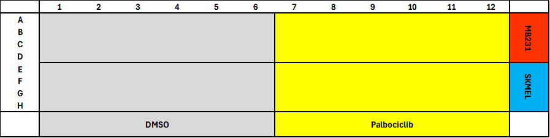

**This is the plate layout.**

## These scripts cover:

1. Data import into R from InCarta
2. Adding data labels and filtering
3. Making basic plots comparing cell number by column and row
4. Making plate maps

As with most things in R - there are more ways than this to achieve similar results but this should be a good template for using your own files.

*Thanks to Emily O’Sullivan for the plate map scripts*

## Data Wrangling

Often the data-wrangling steps are the most complicated and it is important to make sure you are selecting the columns you need as you go through.

```r
# Load required packages
library("gplots")
library("RColorBrewer")
library("matrixStats")
library("plyr")
library("dplyr")
library("data.table")
library("stringr")
library("ggplot2")
library("Rtsne")
library("readxl")
library(platetools)
library(stringr)



# Import CSV File
Data <- fread("Summary Data.csv")

# List the variables you want to keep
Variable_Names <- c("Row", "Column", "Nuclei Nuclei Count wv1", "Nuclei Area wv1", "Cells Area wv2")

# Use your variables list to select the columns
Data_Tidy <- Data %>%
  select(all_of(Variable_Names))

# Add meaningful labels based on columns
Data_Labelled <- Data_Tidy %>%
  mutate(Treatment = case_when(Column %in% 1:6 ~ "DMSO",
                               Column %in% 7:12 ~ "Palbo"),
         Cells = case_when(Row %in% c("A", "B", "C", "D") ~ "MB231",
                           Row %in% c("E", "F", "G", "H") ~ "SKMEL"))

# Filter and split data as needed
Data_MB231 <- Data_Labelled %>%
  filter(Cells == "MB231")

Data_SKMEL <- Data_Labelled %>%
  filter(Cells == "SKMEL")
```

## Making and Saving Plots

These plots allow us to assess the consistency of our technical replicates (wells) across rows and columns.

Patterns in this data might indicate inconsistency when seeding or other technical errors that can then be addressed.

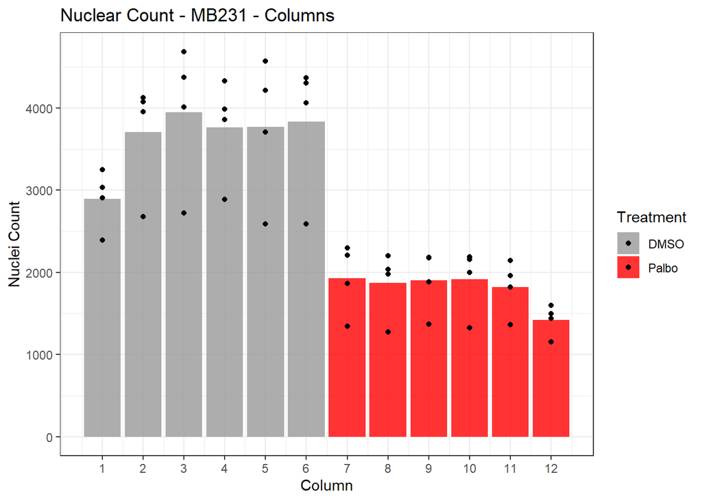

```r
# Make a Nuclear Count Plot of Columns - MB231
ggplot(Data_MB231, aes(x = Column, y = `Nuclei Nuclei Count wv1`, fill = Treatment)) +
  geom_bar(stat = "summary", fun = "mean", position = "dodge", alpha = 0.8) +
  geom_point(position = position_dodge(width = .9), color = "black") +
  theme_bw() +
  scale_fill_manual(values = c("#999999", "red")) +
  labs(title = "Nuclear Count - MB231 - Columns", x = "Column", y = "Nuclei Count") +
  guides(fill = guide_legend()) +
  scale_x_continuous(breaks = seq(min(Data_MB231$Column), max(Data_MB231$Column), by = 1))
```

```r
# Save the plot
ggsave("Nuclear Count Plot MB231 - Columns.png", plot = last_plot(), width = 6, height = 4, dpi = 300)
```

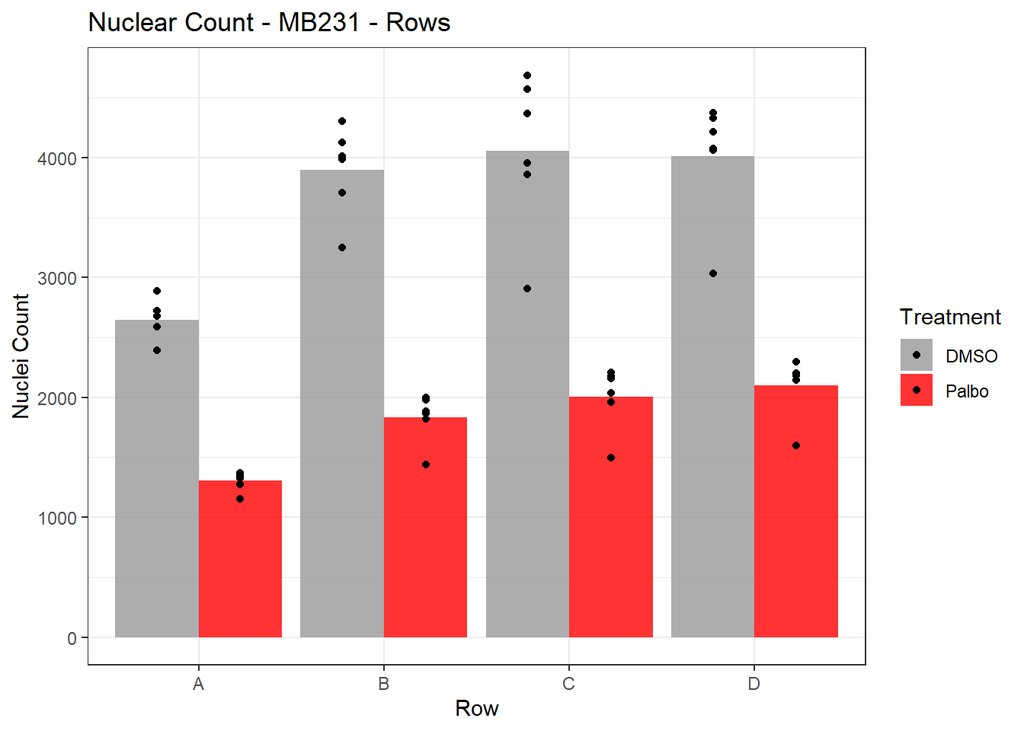

```r
# Convert Row to a factor
Data_MB231$Row <- factor(Data_MB231$Row, levels = c("A", "B", "C", "D"))

# Make a Nuclear Count Plot of Rows - MB231
ggplot(Data_MB231, aes(x = Row, y = `Nuclei Nuclei Count wv1`, fill = Treatment)) +
  geom_bar(stat = "summary", fun = "mean", position = "dodge", alpha = 0.8) +
  geom_point(position = position_dodge(width = .9), color = "black") +
  theme_bw() +
  scale_fill_manual(values = c("#999999", "red")) +
  labs(title = "Nuclear Count - MB231 - Rows", x = "Row", y = "Nuclei Count") +
  guides(fill = guide_legend()) +
  scale_x_discrete(drop = FALSE)
```

```r
# Save the plot
ggsave("Nuclear Count Plot MB231 - Rows.png", plot = last_plot(), width = 6, height = 4, dpi = 300)
```

## Making and Plate Map - Heatmaps

These are similar to the InCarta visualisation you get but are more controlable.

They are useful for visualising variability across your plate or, as in this case, clearly seeing the effect of treatments.

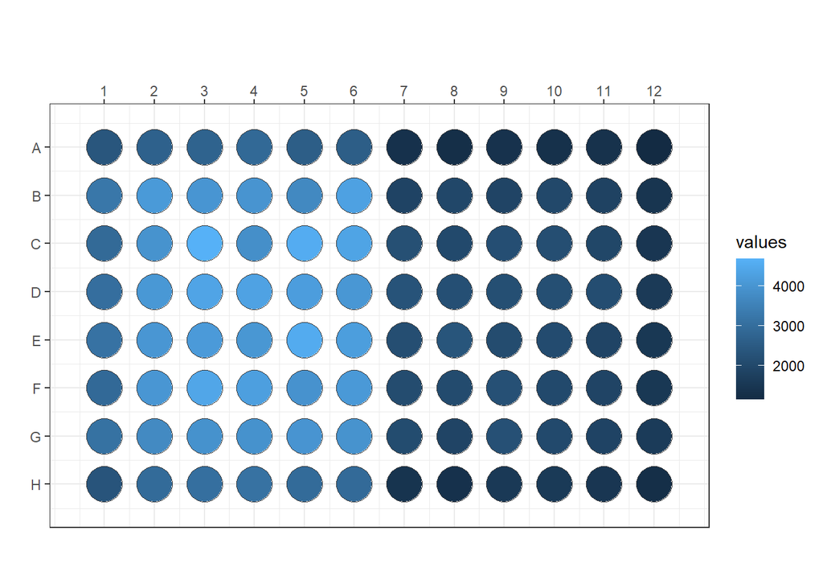

```r
#Update Data frame for heatmap
Data <- Data_Labelled %>%
  mutate(
    `NEW WELL LABEL` = str_c(Row, str_pad(Column, 2, pad = "0"))  # Combine Row and zero-padded Column
  )

# Generate heatmap using platetools
raw_map(data = Data$`Nuclei Nuclei Count wv1`,
        well = Data$`NEW WELL LABEL`,
        plate = 96)
```

```r
# Save platetools heatmap
ggsave("Nuclei_Count_Heatmap_platetools.png", plot = last_plot(), width = 8, height = 6, dpi = 300)
```

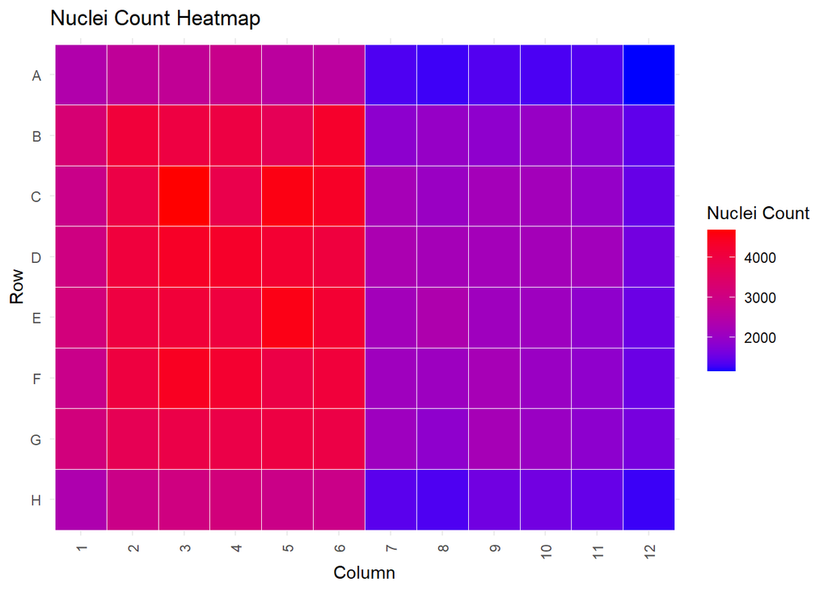

```r
# Generate a heatmap using ggplot2 for a more customized approach
Data$Column <- as.factor(Data$Column)
Data$Row <- factor(Data$Row, levels = rev(c("A", "B", "C", "D", "E", "F", "G", "H")))  # Reverse levels for ggplot

ggplot(Data, aes(x = Column, y = Row, fill = `Nuclei Nuclei Count wv1`)) +
  geom_tile(color = "white") +
  scale_fill_gradient(low = "blue", high = "red", na.value = "white") +
  theme_minimal() +
  labs(title = "Nuclei Count Heatmap",
       x = "Column",
       y = "Row",
       fill = "Nuclei Count") +
  theme(axis.text.x = element_text(angle = 90, vjust = 0.5, hjust=1))
```

```r
# Save ggplot2 heatmap
ggsave("Nuclei_Count_Heatmap_ggplot2.png", plot = last_plot(), width = 8, height = 6, dpi = 300)
```